# Efficient R (update)

Scientific workflows: Tools and Tips 🛠️

Dr. Selina Baldauf

2025-06-19

## What is this lecture series?

### Scientific workflows: Tools and Tips 🛠️

📅 Every 3rd Thursday 🕓 4-5 p.m. 📍 Webex

- One topic from the world of scientific workflows
- Material provided [online](https://selinazitrone.github.io/tools_and_tips/)
- If you don’t want to miss a lecture
  - [Subscribe to the mailing list](https://lists.fu-berlin.de/listinfo/toolsAndTips)

## Main reference

Efficient R book by Gillespie and Lovelace, read it [here](https://bookdown.org/csgillespie/efficientR/)

[figure not shown]

## What is efficiency?

$$\textsf{efficiency} = \frac{\textsf{work done}}{\textsf{unit of effort}}$$

**Computational efficiency**

💻 Computation time  
💾 Memory usage

**Programmer efficiency**

🧍 How long does it take to

- *write* code?
- *maintain* code?
- *read* and *understand* the code?

**Tradeoffs** and **Synergies** between these types of efficiencies

## Today

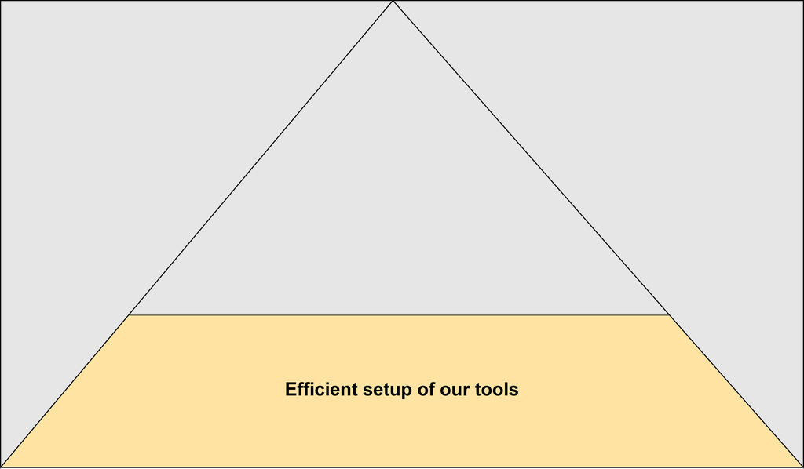

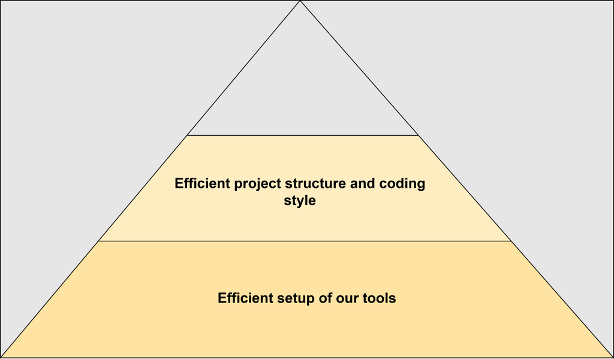

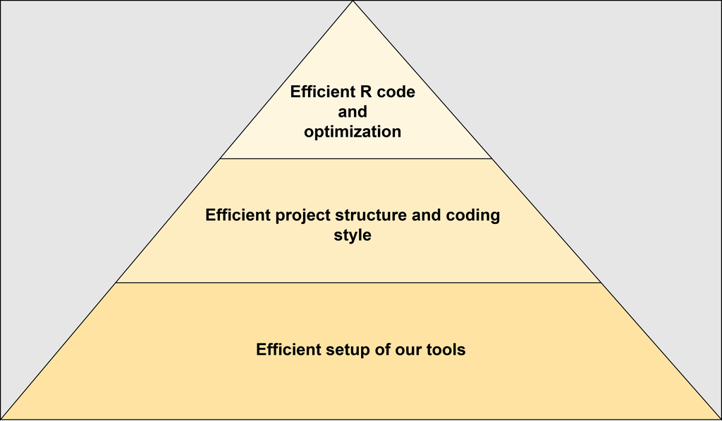

**Principles** and **tools** to make R programming more efficient for the 💻

Check out my talk [“Write R code that lasts”](https://selinazitrone.github.io/tools_and_tips/sessions/10_r-code-that-lasts.html) for basics

## Is R slow?

- R is slow compared to other programming languages (e.g. C++, Julia).
  - R is designed to make statistical programming & data analysis **easy** and **interactive**, not fast
- R is the not the most memory efficient language
- But: R is fast and memory efficient enough for most tasks.

## Should I optimize?

> It’s easy to get caught up in trying to remove all bottlenecks. Don’t! **Your time is valuable** and is **better spent analysing your data**, not eliminating possible inefficiencies in your code. **Be pragmatic**: don’t spend hours of your time to save seconds of computer time.  
> (Hadley Wickham in [Advanced R](https://adv-r.hadley.nz/perf-improve.html))

#### Think about

- How much time do I **save** vs. **spend** with optimizing?
- **How often** do I run the code?
- Trade-offs between **readability** and **efficiency**

## Should I optimize?

If your code is too slow for you, you can go through these steps:

1. Think if you can **run the code somewhere else**

## Run the code somewhere else

- Use RStudio **background jobs**

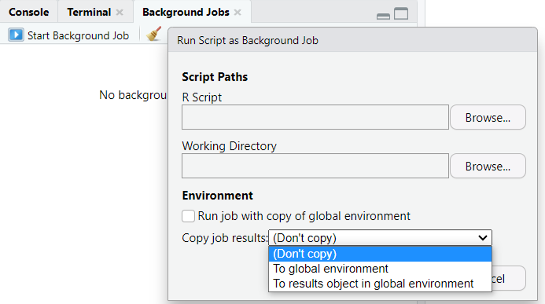

- Start your R script from the command line

```bash
Rscript my_script.R
```

- Run it on a cluster (e.g. [FU Curta](https://www.fu-berlin.de/en/sites/high-performance-computing/Rechenressourcen/index.html))

## Should I optimize?

If your code is to slow for you, you can go through these steps:

1. Think if you can **run the code somewhere else**
2. **Identify the critical** (slow) **parts** of your code
3. Then **optimize only the bottlenecks**

# Profiling and benchmarking

> Measure the speed and memory usage of your code

## Profiling R code

What are the speed & memory bottlenecks in my code?

- Use the [`profvis` package](https://rstudio.github.io/profvis/)

## Profiling R code

You can profile a section of code like this:

```r
# install.packages("profvis")
library(profvis)

# Create a data frame with 150 columns and 400000 rows
df <- data.frame(matrix(rnorm(150 * 400000), nrow = 400000))

profvis({
  # Calculate mean of each column and put it in a vector
  means <- apply(df, 2, mean)

  # Subtract mean from each value in the table
  for (i in seq_along(means)) {
    df[, i] <- df[, i] - means[i]
  }
})
```

## Profiling R code

Profvis flame graph shows time and memory spent in each line of code.

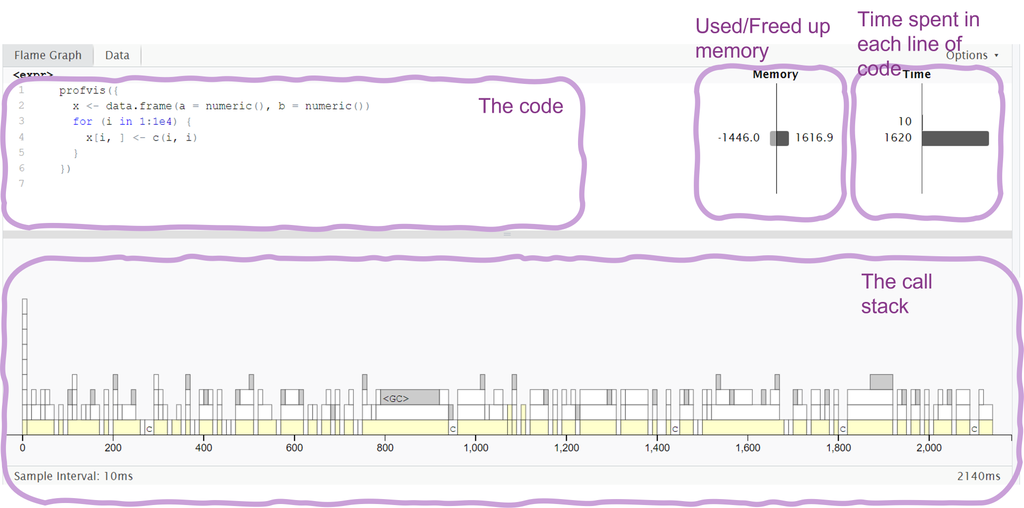

## Profiling R code

Profvis data view for details on time spent in each function in the call stack.

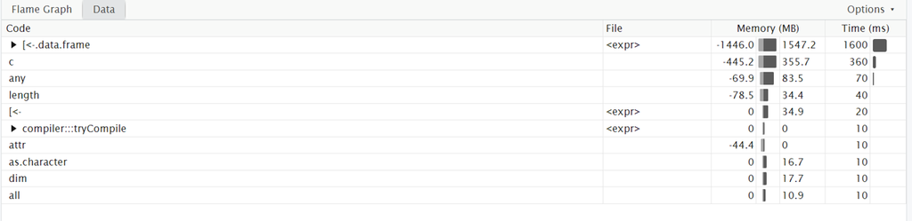

## Profiling R code

You can also interactively profile code in RStudio:

- Go to **Profile -> Start profiling**
- Now interactively run the code you want to profile
- Go to **Profile -> Stop profiling** to see the results

## Benchmarking R code

Which version of the code is faster?

```r
# Fill a data frame in a loop
f1 <- function() {
  x <- data.frame(a = numeric(), b = numeric())
  for (i in 1:1e4) {
    x[i, ] <- c(i, i)
  }
}

# Fill a data frame directly with vectors
f2 <- function() {
  x <- data.frame(a = 1:1e4, b = 1:1e4)
}
```

## Benchmarking R code - the easy way

Use the `tictoc` package to get a quick overview of the time a section of code takes

```r
# install.packages("tictoc")
library(tictoc)

tic()
f1()
toc()
```

```
#> 1.12 sec elapsed
```

```r
tic()
f2()
toc()
```

```
#> 0 sec elapsed
```

## Benchmarking R code

Use the `microbenchmark` package to compare the functions:

```r
# install.packages("microbenchmark")
library(microbenchmark)

compare_functions <- microbenchmark(
  old = f1(),
  new = f2(),
  times = 10 # default is 100
)

compare_functions
```

```
#> Unit: microseconds
#>  expr     min        lq       mean     median      uq       max neval cld
#>   old 1063482 1107142.4 1139802.19 1135030.70 1176419 1210050.0    10  a
#>   new      62      76.8     247.96     178.35     183    1267.8    10   b
```

We can look at benchmarking results using ggplot

```r
library(ggplot2)
autoplot(compare_functions)
```

## Benchmarking R code

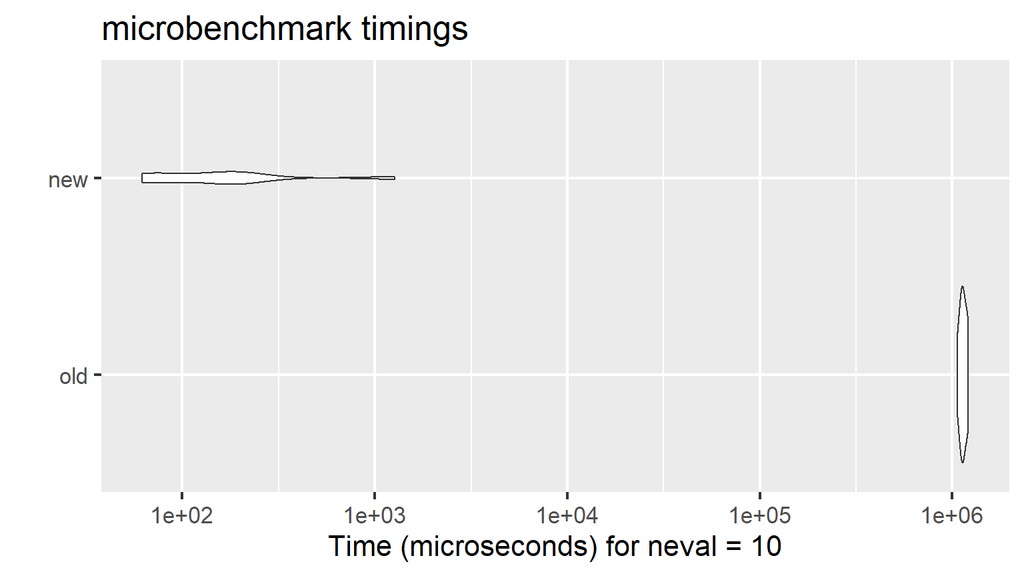

# Optimize your code

- Basic principles
- Data analysis bottlenecks
- Advanced optimization: Parallelization and C++

# Basic principles

## Vectorize your code

- Vectors are central to R programming
- R is optimized for vectorized code
  - Implemented directly in C/Fortran
- Vector operations can often replace for-loops in R
- If there is a vectorized version of a function: Use it

## Vectorize your code

**Example**: Calculate the log of every value in a vector and sum up the result

```r
# A vector with 1 million values
x <- 1:1e6

microbenchmark(
  for_loop = {
    log_sum <- 0
    for (i in 1:length(x)) {
      log_sum <- log_sum + log(x[i])
    }
  },
  sum = sum(log(x)),
  times = 10
)
```

```
#> Unit: milliseconds
#>      expr     min      lq     mean  median      uq     max neval cld
#>  for_loop 58.7096 59.0902 59.96390 59.5209 60.4307 63.5593    10  a
#>       sum 35.8210 36.6466 37.21634 37.0020 37.9745 38.8886    10   b
```

## For-loops in R

- For-loops are **relatively slow** and it is easy to make them even slower with bad design
- Often they are used when vectorized code would be better
- For loops can often be replaced, e.g. by
  - Functions from the apply family (e.g. `apply`, `lapply`, …)
  - Vectorized functions (e.g. `sum`, `colMeans`, …)
  - Vectorized functions from the [`purrr` package](https://purrr.tidyverse.org/) (e.g. `map`)

But: For loops are not necessarily bad, **sometimes** they are the **best solution** and **more readable** than vectorized code.

## Cache variables

If you use a value multiple times, store it in a variable to avoid re-calculation

**Example**: Calculate column means and normalize them by the standard deviation

```r
# A matrix with 1000 columns
x <- matrix(rnorm(10000), ncol = 1000)

microbenchmark(
  no_cache = apply(x, 2, function(i) mean(i) / sd(x)),
  cache = {
    sd_x <- sd(x)
    apply(x, 2, function(i) mean(i) / sd_x)
  }
)
```

```
#> Unit: milliseconds
#>      expr     min      lq      mean   median       uq      max neval cld
#>  no_cache 57.9128 60.9763 63.638999 62.88575 64.68335 111.1956   100  a
#>     cache  3.3494  3.5692  3.676188  3.63415  3.71695   5.2457   100   b
```

# Efficient data analysis

## Efficient workflow

- Prepare the data to be clean and concise for analysis
  - Helps to avoid unnecessary calculations
- Save intermediate results
  - Don’t re-run time-consuming steps if not necessary
- Use the right packages and functions

## Read data

**Example:** Read csv data on worldwide emissions of greenhouse gases (~14000 rows, 7 cols).

- Base-R functions to read csv files are:
  - `read.table`
  - `read.csv`
- There are many alternatives to read data, e.g.:
  - `read_csv` from the `readr` package (tidyverse)
  - `fread` from the `data.table` package
  - `read_csv_arrow` from the `arrow` package

## Read data

Compare some alternative reading functions

```r
file_path_csv <- here::here("slides/data/ghg_ems_large.csv")

compare_input <- microbenchmark::microbenchmark(
  read.csv = read.csv(file_path_csv),
  read_csv = readr::read_csv(file_path_csv, progress = FALSE, show_col_types = FALSE),
  fread = data.table::fread(file_path_csv, showProgress = FALSE),
  read_csv_arrow = arrow::read_csv_arrow(file_path_csv),
  times = 10
)

autoplot(compare_input)
```

## Read data

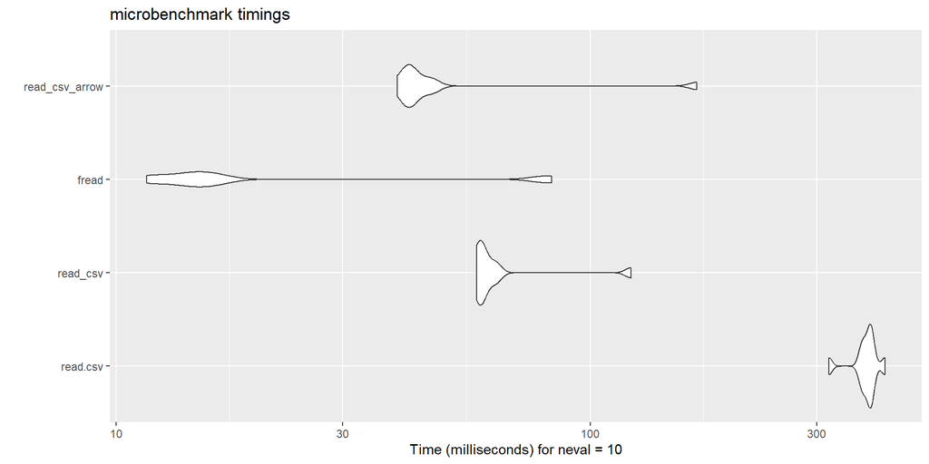

## Use plain text data

Reading plain text is faster than excel files

```r
file_path_xlsx <- here::here("slides/data/ghg_ems_large.xlsx")

compare_excel <- microbenchmark(
  read_csv = readr::read_csv(file_path_csv),
  read_excel = readxl::read_excel(file_path_xlsx),
  times = 10
)

autoplot(compare_excel)
```

## Use plain text data

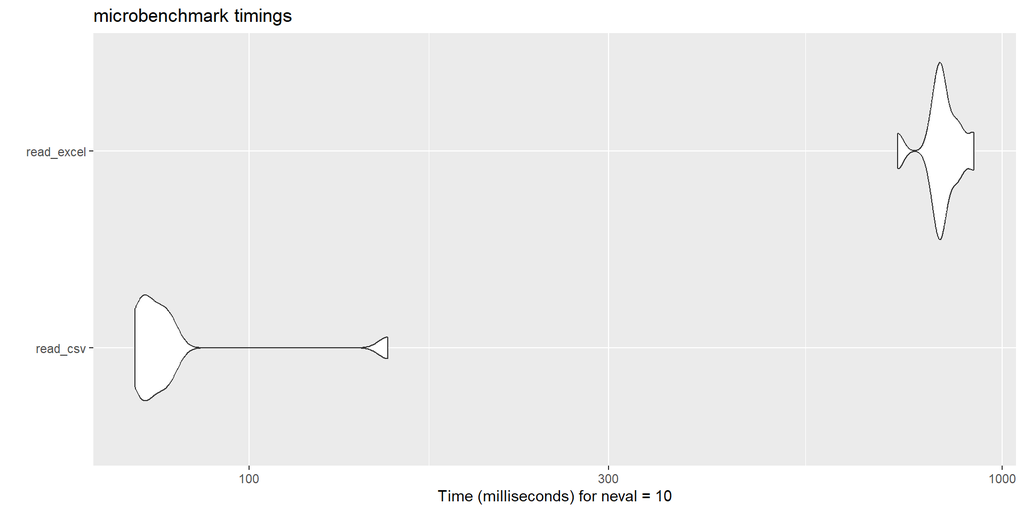

## Write data

- Base-R functions to write csv files are:
  - `write.table`
  - `write.csv`
- Faster alternatives are
  - `write_csv` from the `readr` package (tidyverse)
  - `fwrite` from the `data.table` package
  - `write_csv_arrow` from the `arrow` package

## Efficient data manipulation

Different packages offer fast and efficient data manipulation and analysis:

- `dplyr` package has a C++ backend and is often faster than base R
- `data.table` package is fast and memory efficiency
  - Syntax is quite different from base R and `tidyverse`
- `collapse` package is a C++ based and specifically developed for fast data analysis
  - Works together with both `tidyverse` and `data.table` workflows
  - Many functions similar to base R or `dplyr` just with prefix “f” (e.g. `fselect`, `fmean`, …)
- `arrow` package for efficient reading, processing and writing of large datasets (even larger than RAM)

## Summarize data by group

**Example**: Summarize mean carbon emissions from Electricity by Country

```r
library(data.table)
library(dplyr)
library(collapse)
```

## Summarize data by group

**Example**: Summarize mean carbon emissions from Electricity by Country

```r
# 1. The data table way
# Convert the data to a data.table
setDT(ghg_ems)
summarize_dt <- function() {
  ghg_ems[, mean(Electricity, na.rm = TRUE), by = Country]
}

# 2. The dplyr way
summarize_dplyr <- function() {
  ghg_ems |>
    group_by(Country) |>
    summarize(mean_e = mean(Electricity, na.rm = TRUE))
}

# 3. The collapse way
summarize_collapse <- function() {
  ghg_ems |>
    fgroup_by(Country) |>
    fsummarise(mean_e = fmean(Electricity))
}
```

## Efficient data manipulation

**Example**: Summarize mean carbon emissions from Electricity by Country

```r
# compare the speed of all versions
microbenchmark(
  dplyr = summarize_dplyr(),
  data_table = summarize_dt(),
  collapse = summarize_collapse(),
  times = 10
)
```

```
#> Unit: microseconds
#>        expr    min     lq    mean  median     uq     max neval cld
#>       dplyr 2155.2 2179.4 3598.01 2262.65 2479.2 14360.4    10  a
#>  data_table 1276.2 1329.9 2012.95 1474.85 1786.0  5818.1    10  ab
#>    collapse  157.1  177.2  382.28  203.65  235.0  1159.0    10   b
```

## Select columns

```r
microbenchmark(
  dplyr = select(ghg_ems, Country, Year, Electricity, Transportation),
  data_table = ghg_ems[, .(Country, Electricity, Transportation)],
  collapse = fselect(ghg_ems, Country, Electricity, Transportation),
  times = 10
)
```

```
#> Unit: microseconds
#>        expr   min    lq   mean median    uq    max neval cld
#>       dplyr 554.8 586.0 892.32  611.5 739.8 3132.2    10  a
#>  data_table 331.3 333.9 655.54  351.8 417.7 3321.8    10  ab
#>    collapse   4.4   4.8  13.54    7.6   8.7   72.3    10   b
```

# Advanced optimization

> Parallelization and C++

## Parallelization

By default, R works on one core but CPUs have multiple cores

```r
# Find out how many cores you have with the parallel package
# install.packages("parallel")
parallel::detectCores()
```

```
#> [1] 32
```

Sequential

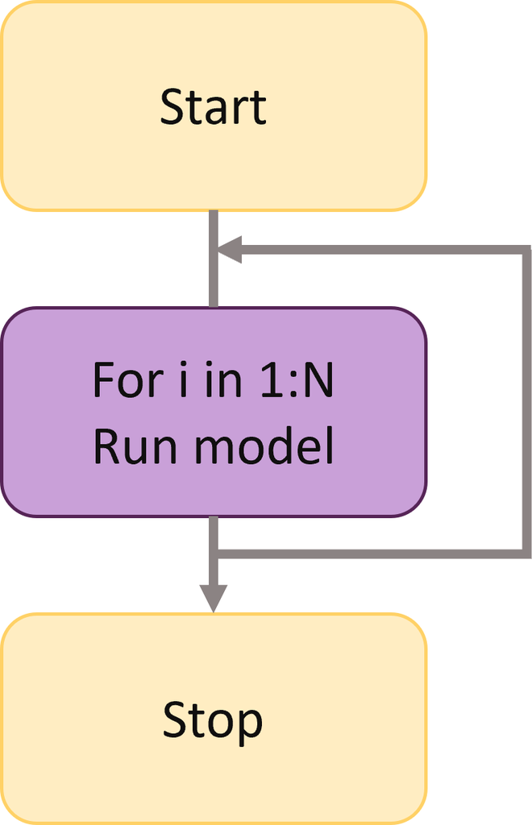

Parallel

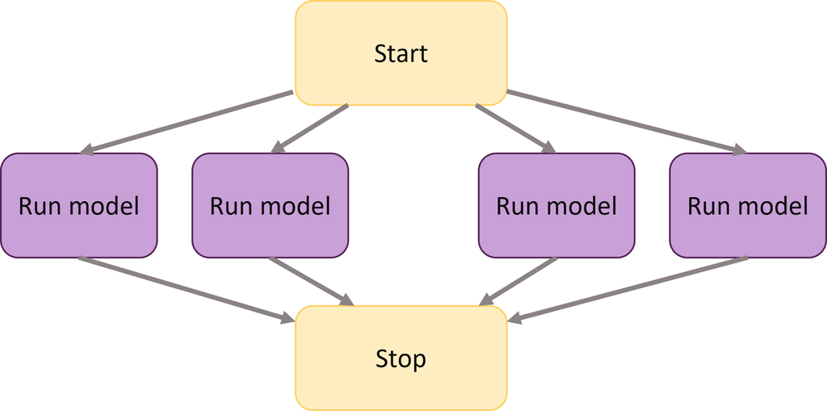

## Parallelization with the futureverse

- `future` is a framework to help you parallelize existing R code
  - Parallel versions of base R apply family
  - Parallel versions of `purrr` functions
  - Parallel versions of `foreach` loops
- Find more details [here](https://www.futureverse.org/)
- Find a tutorial for different use cases [here](https://henrikbengtsson.github.io/future-tutorial-user2022)

## A slow example

Let’s create a very slow square root function

```r
slow_sqrt <- function(x) {
  Sys.sleep(1) # simulate 1 second of computation time
  sqrt(x)
}
```

Before you run anything in parallel, tell R how many cores to use:

```r
# Load future package
library(future)
# Plan parallel session with 6 cores
plan(multisession, workers = 6)
```

## Parallel apply functions

To run the function on a vector of numbers we could use

**Sequential** **`lapply`**

```r
# create a vector of 10 numbers
x <- 1:10
tic()
result <- lapply(x, slow_sqrt)
toc()
```

```
#> 10.09 sec elapsed
```

**Parallel** **`future_lapply`**

```r
# Load future.apply package
library(future.apply)

tic()
result <- future_lapply(x, slow_sqrt)
toc()
```

```
#> 2.6 sec elapsed
```

Use `parallel::detectCores()` to find out how many cores you have.

## Parallel apply functions

Selected base R apply functions and their future versions:

| base | future.apply |
| --- | --- |
| `lapply` | `future_lapply` |
| `sapply` | `future_sapply` |
| `vapply` | `future_vapply` |
| `mapply` | `future_mapply` |
| `tapply` | `future_tapply` |
| `apply` | `future_apply` |
| `Map` | `future_Map` |

## Parallel for loops

A normal for loop:

```r
z <- list()
for (i in 1:10) {
  z[i] <- slow_sqrt(i)
}
```

Use `foreach` to write the same loop

```r
library(foreach)
z <- foreach(i = 1:10) %do%
  {
    slow_sqrt(i)
  }
```

## Parallel for loops

Use `doFuture` and `foreach` package to parallelize for loops

The **sequential** version

```r
library(foreach)

tic()
z <- foreach(i = 1:10) %do%
  {
    slow_sqrt(i)
  }
toc()
```

```
#> 10.17 sec elapsed
```

The **parallel** version

```r
library(doFuture)

tic()
z <- foreach(i = 1:10) %dofuture%
  {
    slow_sqrt(i)
  }
toc()
```

```
#> 2.25 sec elapsed
```

## Future `purrr` functions

The [`furrr` package](https://furrr.futureverse.org/) offers parallel versions of [`purrr` functions](https://purrr.tidyverse.org/)

The **sequential** version

```r
library(purrr)

# the purrr version
tic()
z <- map(x, slow_sqrt)
toc()
```

```
#> 10.11 sec elapsed
```

The **parallel** version

```r
library(furrr)

# the furrr version
tic()
z <- future_map(x, slow_sqrt)
toc()
```

```
#> 2.72 sec elapsed
```

## Close multisession

When you are done working in parallel, explicitly close your multisession:

```r
# close the multisession plan
plan(sequential)
```

## Replace slow code with C++

- Use the [`Rcpp` package](https://www.rcpp.org/) to re-write R functions in C++
- `Rcpp` is also used internally by many R packages to make them faster
- Requirements:
  - C++ compiler installed
  - Some knowledge of C++
- See [this book chapter](https://csgillespie.github.io/efficientR/performance.html#rcpp) and the [online documentation](https://www.rcpp.org/) for more info

## Rewrite a function in C++

**Example:** R function to calculate Fibonacci numbers

```r
# A function to calculate Fibonacci numbers
fibonacci_r <- function(n) {
  if (n < 2) {
    return(n)
  } else {
    return(fibonacci_r(n - 1) + fibonacci_r(n - 2))
  }
}
```

```r
# Calculate the 30th Fibonacci number
fibonacci_r(30)
```

```
#> [1] 832040
```

## Rewrite a function in C++

Use `cppFunction` to rewrite the function in C++:

```r
library(Rcpp)

# Rewrite the fibonacci_r function in C++
fibonacci_cpp <- cppFunction(
  'int fibonacci_cpp(int n){
    if (n < 2){
      return(n);
    } else {
      return(fibonacci_cpp(n - 1) + fibonacci_cpp(n - 2));
    }
  }'
)
```

```r
# calculate the 30th Fibonacci number
fibonacci_cpp(30)
```

```
#> [1] 832040
```

## Rewrite a function in C++

You can also source C++ functions from C++ scripts.

C++ script `fibonacci.cpp`:

```cpp
#include "Rcpp.h"

// [[Rcpp::export]]
int fibonacci_cpp(const int x) {
   if (x < 2) return(x);
   return (fibonacci(x - 1)) + fibonacci(x - 2);
}
```

Then source the function in your R script using `sourceCpp`:

```r
sourceCpp("fibonacci.cpp")

# Use the function in your R script like you are used to
fibonacci_cpp(30)
```

## How much faster is C++?

```r
microbenchmark(
  r = fibonacci_r(30),
  rcpp = fibonacci_cpp(30),
  times = 10
)
```

```
#> Unit: microseconds
#>  expr      min       lq      mean    median       uq      max neval cld
#>     r 376508.6 380203.3 382167.28 381371.20 384285.0 390013.1    10  a
#>  rcpp    849.9    865.6    949.38    871.15    926.5   1579.0    10   b
```

# Summary

## Efficient R code and optimization

- First: Can I run it somewhere else?
  - 🔧 Background job or cluster
- If not: Find bottlenecks in your code
  - 🔧 `profvis` package for profiling
  - 🔧 `microbenchmark` package for benchmarking
- Make the critical sections more efficient

# Summary

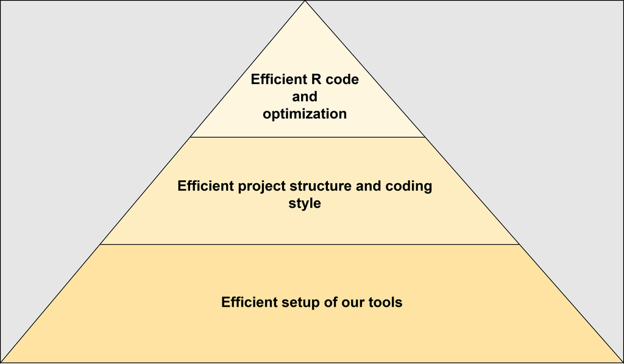

## Next lecture

#### Topic t.b.a.

📅 17th July 🕓 4-5 p.m. 📍 Webex

🔔 [Subscribe to the mailing list](https://lists.fu-berlin.de/listinfo/toolsAndTips)

📧 For topic suggestions and/or feedback send me an email

## Thank you for your attention :)

Questions?

# Appendix

## Cache function results

- Use the [`memoise` package](https://memoise.r-lib.org/)
- If functions are called many times with the same arguments
  - Avoids the recalculation
- Useful to e.g. improve the performance of a shiny app

## Cache function results

**Example**: Create a plot on a subset of the `iris` data set

```r
# Example of using memoise to cache results
library(memoise)
library(ggplot2)

# Remove rows from plotting function
select_iris_species <- function(rows_to_remove) {
  iris_subset <- iris[-rows_to_remove, ]
  # Do a plot on the subset
  p <- ggplot(
    iris_subset,
    aes(x = Sepal.Length, y = Sepal.Width, color = Species)
  ) +
    geom_point()
}

# Version of the function with memoise
select_iris_species_mem <- memoise(select_iris_species)
```

## Cache function results

**Example**: Create a plot on a subset of the `iris` data set

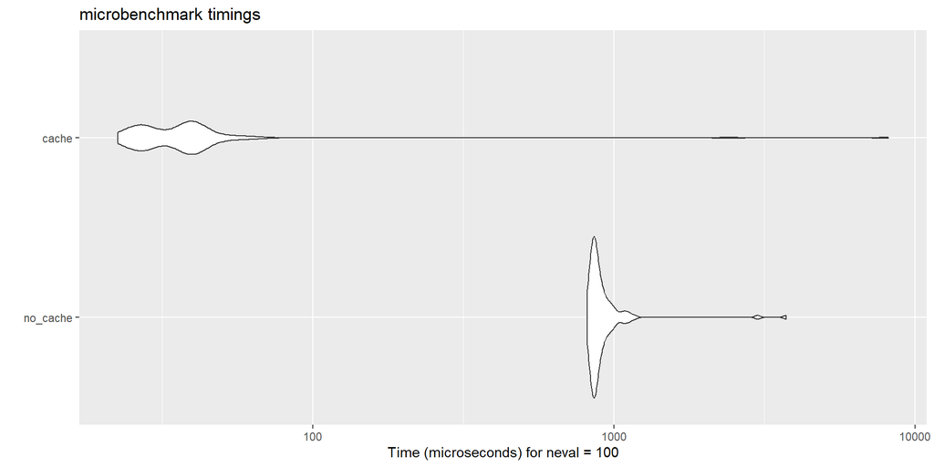

```r
# Compare the two versions
result <- microbenchmark(
  no_cache = select_iris_species(10),
  cache = select_iris_species_mem(10)
)

autoplot(result)
```